# Titanic Data Analysis

Luis Fernando García Acosta

## Titanic Data Analysis

In this pratice we have a Titanic dataset so the goal is to get some information about what happened that day or some data that we can only get from our data. We are going to start with basic data. In this pratice I’m going to use some statistics techniques or knowledges that we can aply in here to see what conclution we can get.

## Basic Data

First I’m going to show you a general summary of what our dataset looks like.

```
##   PassengerId       Survived          Pclass
##  Min.   :  1.0   Min.   :0.0000   Min.   :1.000
##  1st Qu.:223.5   1st Qu.:0.0000   1st Qu.:2.000
##  Median :446.0   Median :0.0000   Median :3.000
##  Mean   :446.0   Mean   :0.3838   Mean   :2.309
##  3rd Qu.:668.5   3rd Qu.:1.0000   3rd Qu.:3.000
##  Max.   :891.0   Max.   :1.0000   Max.   :3.000
##
##                                     Name         Sex           Age
##  Abbing, Mr. Anthony                  :  1   female:314   Min.   : 0.42
##  Abbott, Mr. Rossmore Edward          :  1   male  :577   1st Qu.:20.12
##  Abbott, Mrs. Stanton (Rosa Hunt)     :  1                Median :28.00
##  Abelson, Mr. Samuel                  :  1                Mean   :29.70
##  Abelson, Mrs. Samuel (Hannah Wizosky):  1                3rd Qu.:38.00
##  Adahl, Mr. Mauritz Nils Martin       :  1                Max.   :80.00
##  (Other)                              :885                NA's   :177
##      SibSp           Parch             Ticket         Fare
##  Min.   :0.000   Min.   :0.0000   1601    :  7   Min.   :  0.00
##  1st Qu.:0.000   1st Qu.:0.0000   347082  :  7   1st Qu.:  7.91
##  Median :0.000   Median :0.0000   CA. 2343:  7   Median : 14.45
##  Mean   :0.523   Mean   :0.3816   3101295 :  6   Mean   : 32.20
##  3rd Qu.:1.000   3rd Qu.:0.0000   347088  :  6   3rd Qu.: 31.00
##  Max.   :8.000   Max.   :6.0000   CA 2144 :  6   Max.   :512.33
##                                   (Other) :852
##          Cabin     Embarked
##             :687    :  2
##  B96 B98    :  4   C:168
##  C23 C25 C27:  4   Q: 77
##  G6         :  4   S:644
##  C22 C26    :  3
##  D          :  3
##  (Other)    :186
```

The first thing we can notice is that passengers have an ID so we can say that the total number of passengers is:

```
## [1] 891
```

We can get other clear information from this data we can see that in the Titanic were **314 females** and **577 males**  
Also we can see that we have the passanger’s age the minimun age was about ** 1 year old ** and the maximum age was about **80 years old**  
And the last fact about the data before continuing with the plots, the minimu ticket fare costed **0.0 British Pounds** and the most expensive ticket costed **512 British Pounds**  
We can see that **168 persons** embarked in Cherbourg  
**77 persons** embarked in Queenstown  
**644 persons** embarked in Southampton

## Age

The first thing we are going to analize the age of the passengers

```
##    Min. 1st Qu.  Median    Mean 3rd Qu.    Max.    NA's
##    0.42   20.12   28.00   29.70   38.00   80.00     177
```

We can see the box plot how ages are distributed

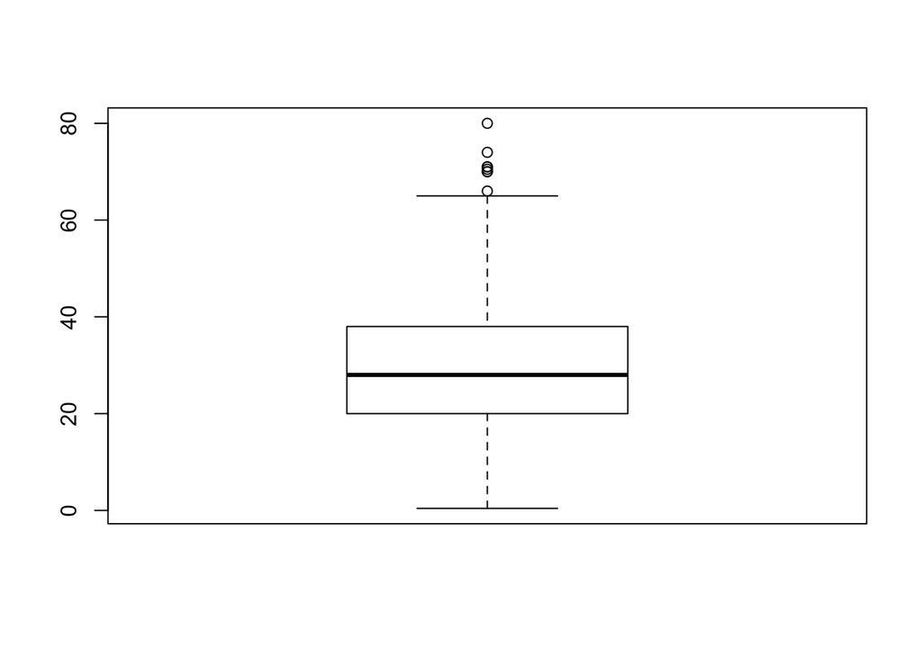

And the histogram shows that the most of the ages were between 20 and 30 years old, really young people

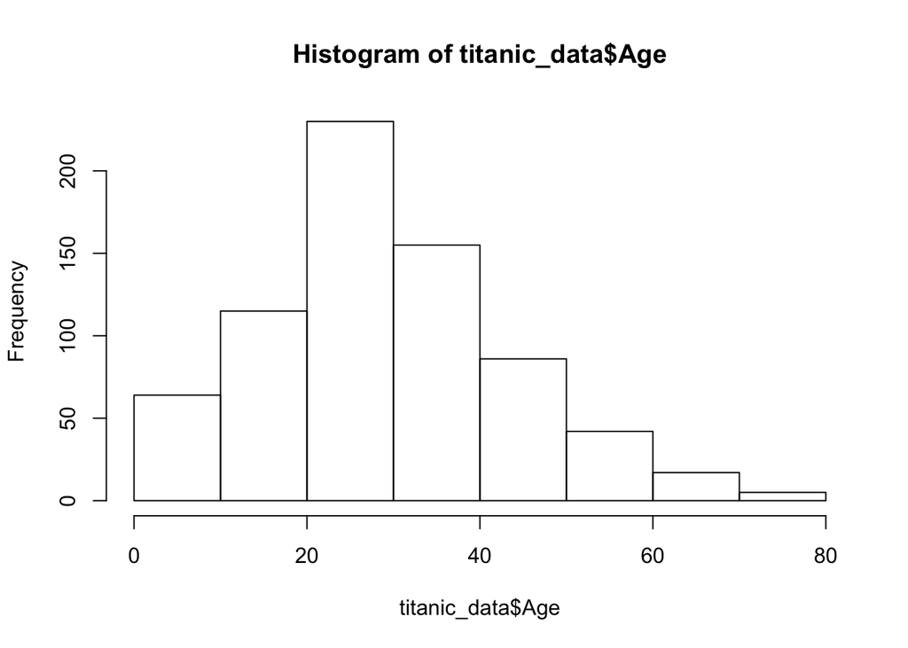

## Class

The second thing we are going to analise is the class of the passengers

```
##    Min. 1st Qu.  Median    Mean 3rd Qu.    Max.
##   1.000   2.000   3.000   2.309   3.000   3.000
```

First we have to understand that there were 3 classes, first class,second and third.  
The most of the people were in third class

```
## [1] 3
```

As we can see in the box plot

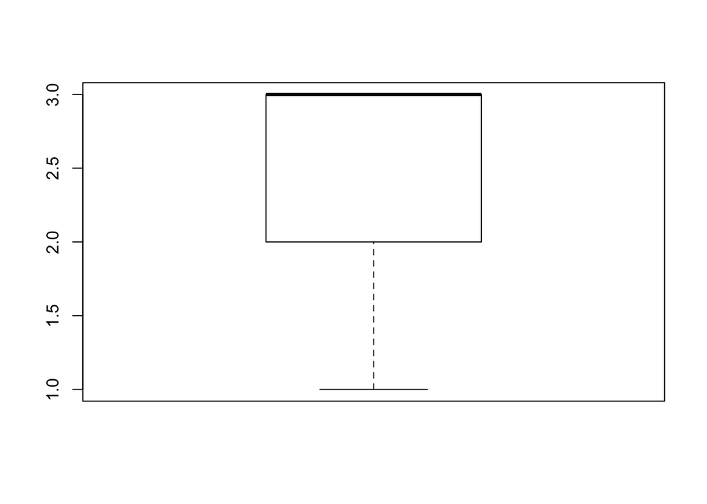

And we can get a estimation how many people were in which class with the next histogram

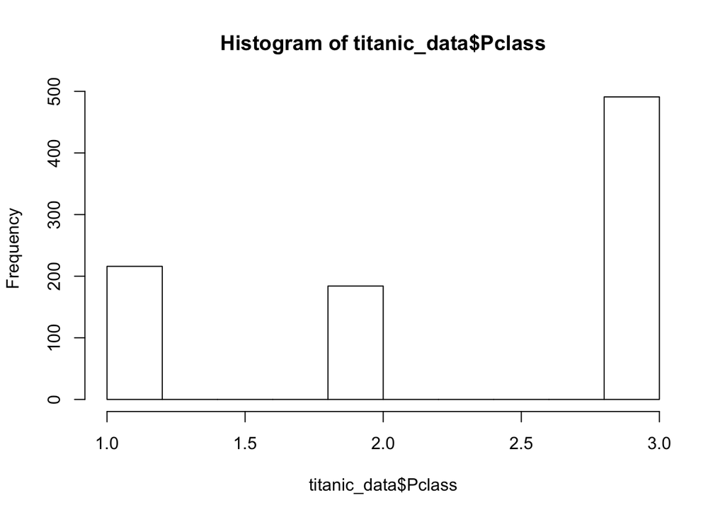

## Survivors

We can get from the data about how many people survived we can see the next histogram of suvivors, 0 means no survivor and 1 means survivor.

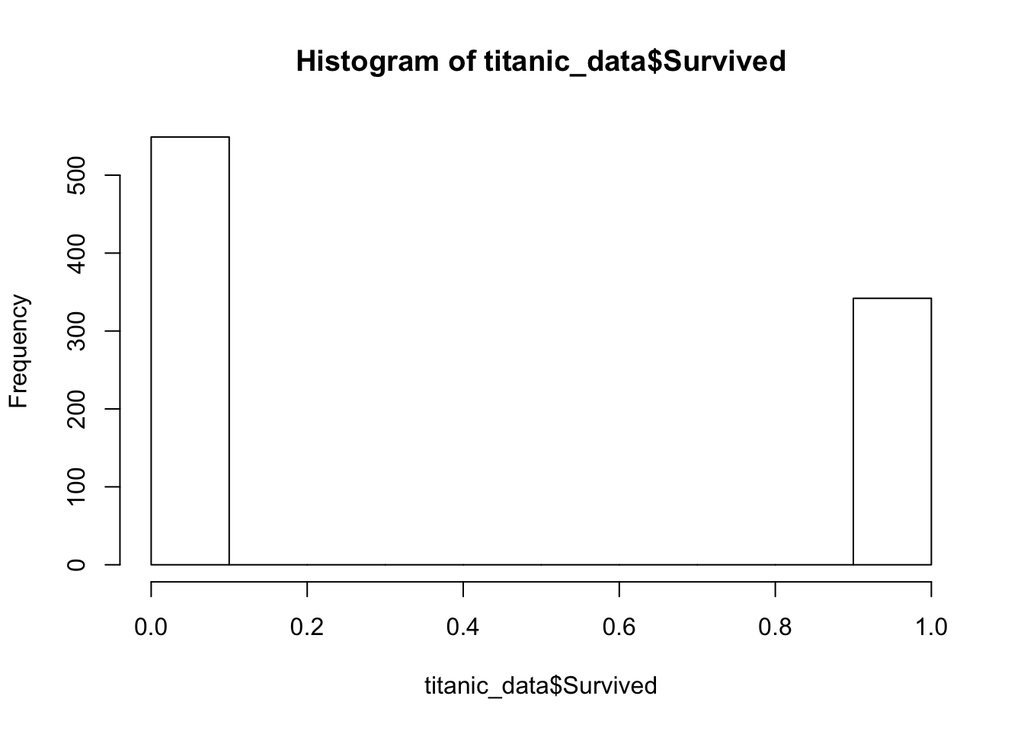

As we can see in the histogram the most people did not survive. We can see it if we get the mode of the dataset in this column.

```
## [1] 0
```

## Numbers of siblings / spouses aboard the Titanic

In this column we can see the number of brothers or sisters or spouses

```
## [1] 0
```

As we can see the most of the people did not travel with family.As the histogram shows the same conclusion

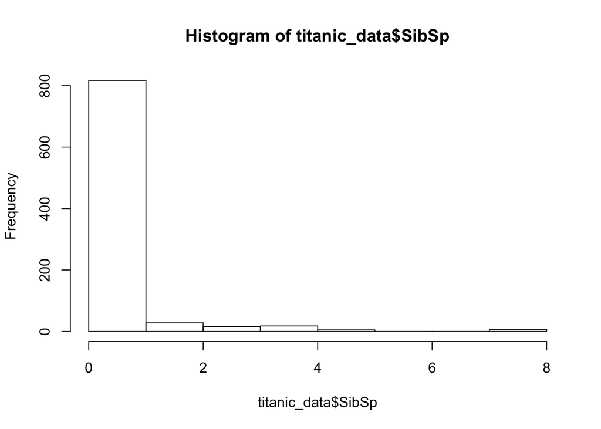

But we can see that there are a few cases where the people did travel with some of their family

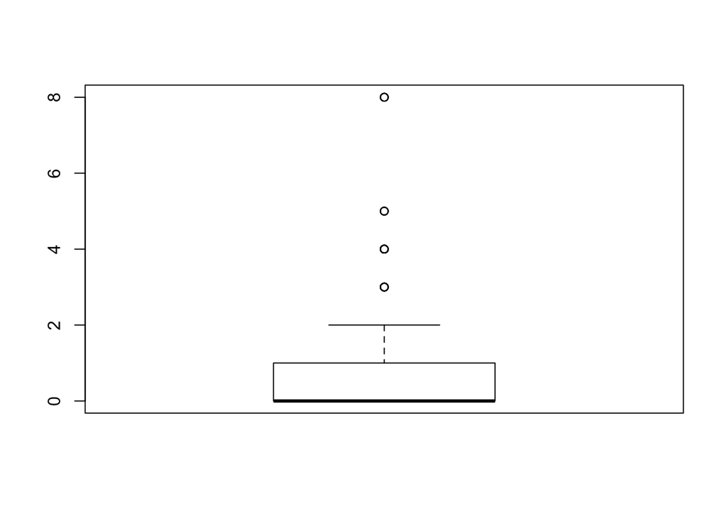

And we can see that our skewness confirms this conlcusion

```
## [1] 3.689128
```

## Number of children or parents

And to confirm that in the Titanic there was not a lot of families we are going to see the number of childrens and parents. We are going to see the mode of this value.

```
## [1] 0
```

And the histogram that shows the same conclusion.

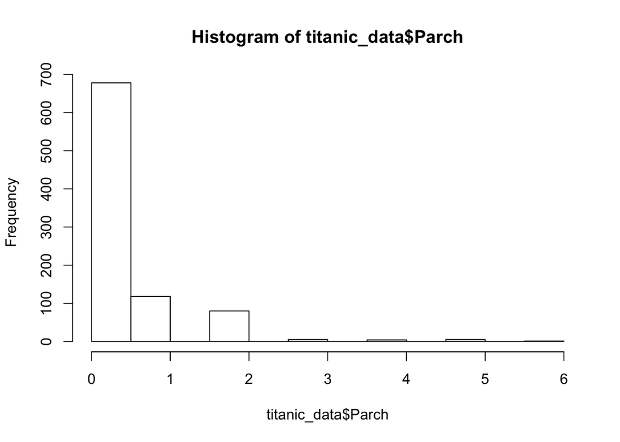

## Extra data

Here I am going to show you some extra data that I can notice.

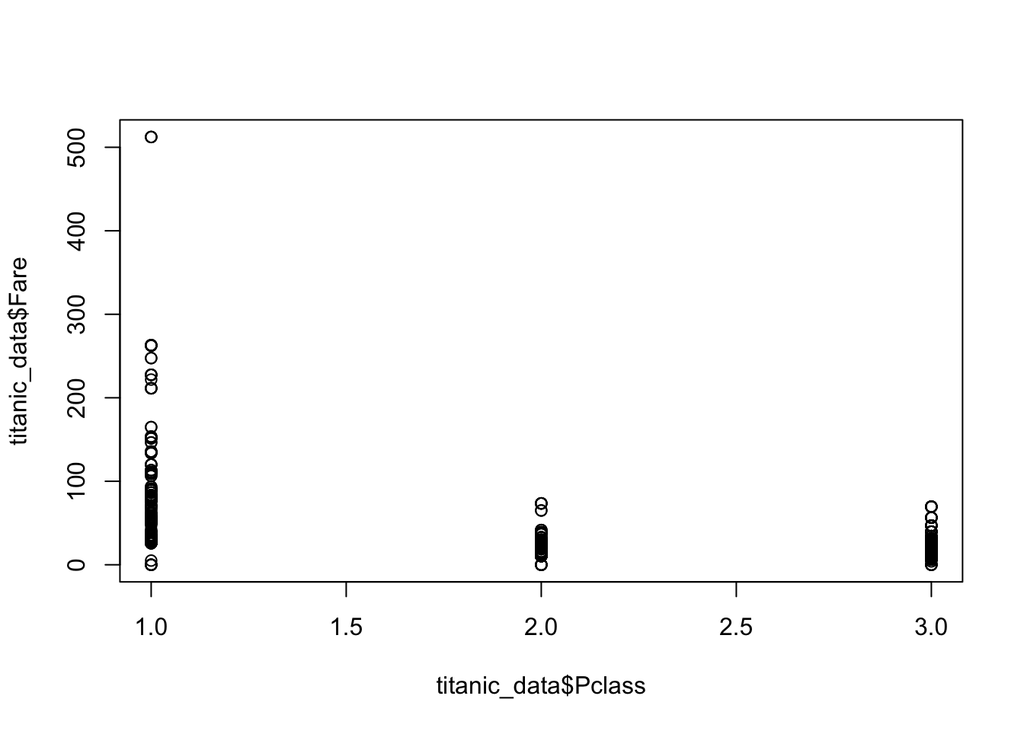

The more expensive tickets fare were paid by the first class passengers.

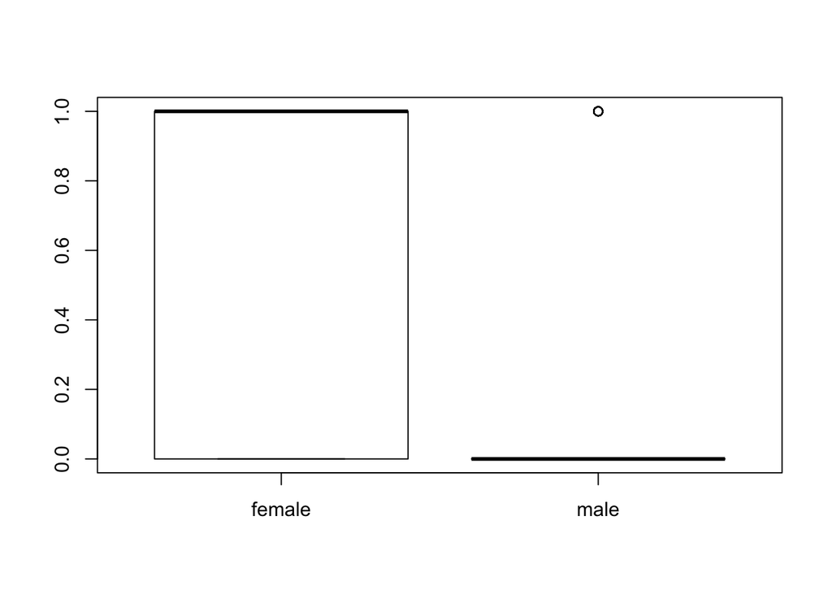

And our final plot shows that the survivors in their most were females.